# Homework 2

Holden Mitchell

9/5/2017

### Homework 2

###### Due Sept. 10th (Sunday)

- 1-17 (percentile, quartile), 1-33 (variance, st. deviation), 1-34 (spread of observations), 1-42 (R), 1-44 (R), 1-49 (R), 1-70 (use years 2012-2016, group), 1-77 (R), 1-79 (R)
- 2-31, 2-61

#### 1-17

Find the lower, middle, and upper quartiles of this data et. Also find the 10th, 15th, and 65th percentiles. What is the interquartile range?

```r
data <- c(128, 121, 134, 136, 136, 118, 123, 109, 120, 116, 125, 128, 121, 129, 130, 131, 127, 119, 114, 134, 110, 136, 134, 125, 128, 123, 128, 133, 132, 136, 134, 129, 132)
quantile(data, c(.25, .50, .75, .10, .15, .65))
```

```
##   25%   50%   75%   10%   15%   65%
## 121.0 128.0 133.0 116.4 118.8 130.8
```

- Lower Quartile: 121.0
- Middle Quartile: 128
- Upper Quartile: 133.5 (133.0 in R)
- 10th Percentile: 114.8 (116.4 in R)
- 15th Percentile: 118.1 (118.8 in R)
- 65th Percentile: 131.1
- Interquartile Range: 133.5 - 121 = 12.5
- The numbers are slightly different when calculated with R and I’m not sure what the discrepancy is.

#### 1-33 (Use data from problem 1-17)

- Find the range, the variance, and the standard deviation of the data set in problem 1-13

```r
summary(data)
```

```
##    Min. 1st Qu.  Median    Mean 3rd Qu.    Max.
##   109.0   121.0   128.0   126.6   133.0   136.0
```

```r
var(data)
```

```
## [1] 57.73864
```

```r
sd(data)
```

```
## [1] 7.598594
```

#### 1-34

Q: Explain why we need measures of variability and what information these measures convey.

A: The variability is needed to show how spread out the data points are. It measures the distribution of the data.

#### 1-42

```r
raw_data <- c(3.45, 4.52, 5.41, 6.00, 5.97, 7.18, 1.12, 5.39, 7.03, 10.25, 11.45, 13.21, 12.00, 14.05, 2.99, 3.28, 17.10, 19.28, 21.09, 12.11, 5.88, 4.65, 3.99, 10.10, 23.00, 15.16, 20.16)
data = data.frame(v1=raw_data)
```

1. Draw an ogive

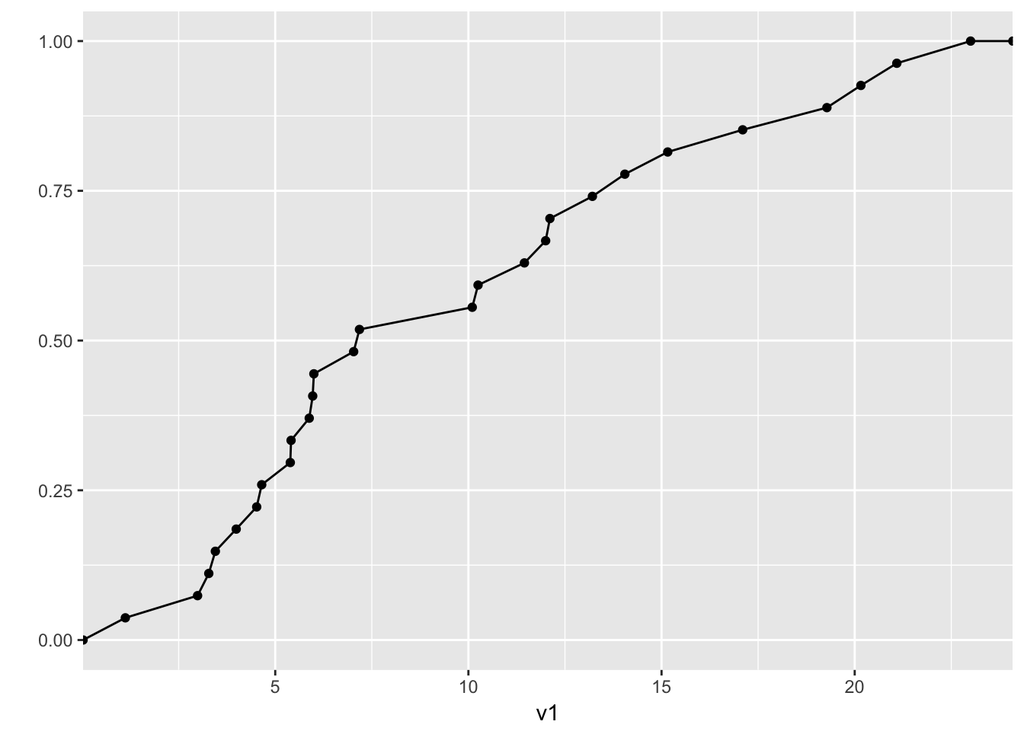

```r
ggplot(data,aes(x=v1)) + stat_ecdf(geom ="point") + ylab("") + stat_ecdf(geom ="line")
```

2. Draw a column graph

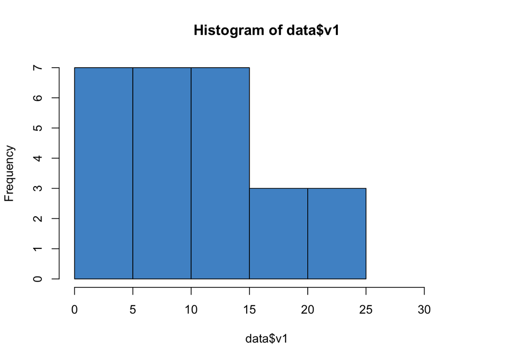

```r
hist(data$v1, xlim = c(0, max(data$v1) + 10), col = "Steelblue3", right = F)
```

#### 1-44 (fix histogram to 1 per value)

```r
data <- c(38.9,32.7,31.1,27.4,25.7,21.6,17.6,17.4,15.0,13.9)
summary(data)
```

```
##    Min. 1st Qu.  Median    Mean 3rd Qu.    Max.
##   13.90   17.45   23.65   24.13   30.18   38.90
```

```r
sd(data)
```

```
## [1] 8.404238
```

Find mean, median, and standard deviation

- Mean = 24.13
- Median = 23.65
- Standard Deviation = 8.40

Draw a bar graph

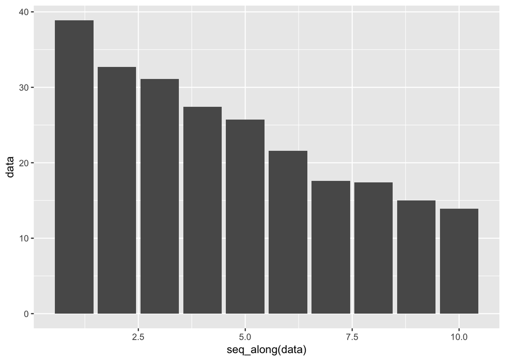

```r
ggplot(data.frame(data),aes(seq_along(data),data))+geom_bar(stat="identity")
```

#### 1-49

Find $\mu$, $\sigma$, $\sigma^2$, draw a box plot, and find the mode and any outliers

```r
  europe <- c(122, 140, 127, 107, 120, 101)
  asia <- c(127,127,127,127,116,120,128,140)
  north_america <- c(140,127,140,130,124)

  all_data <- c(europe, asia, north_america)
  summary(all_data)
```

```
##    Min. 1st Qu.  Median    Mean 3rd Qu.    Max.
##   101.0   121.0   127.0   125.8   129.0   140.0
```

```r
  sd(all_data)
```

```
## [1] 10.50703
```

```r
  sd(all_data)^2
```

```
## [1] 110.3977
```

- $\mu$ = 125.8
- $\sigma$ = 10.50703
- $\sigma^2$ = 110.3977
- Mode = 127

Box Plot

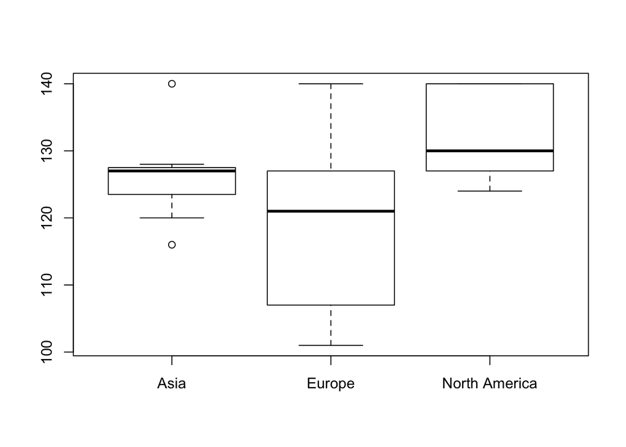

```r
fram = data.frame(y=c(europe,asia,north_america),x=c(rep("Europe",length(europe)),rep("Asia",length(asia)),rep("North America",length(north_america))))
boxplot(y~x, data = fram)
```

- Outliers: Asia - 140, 116

#### 1-70 (Use years 2012-2016)

1. Consumer Data Get data for 2012-2016

```r
consumer <- read.csv(paste(dir, '/cpi.csv', sep = ''), header = TRUE)
```

Make a time plot

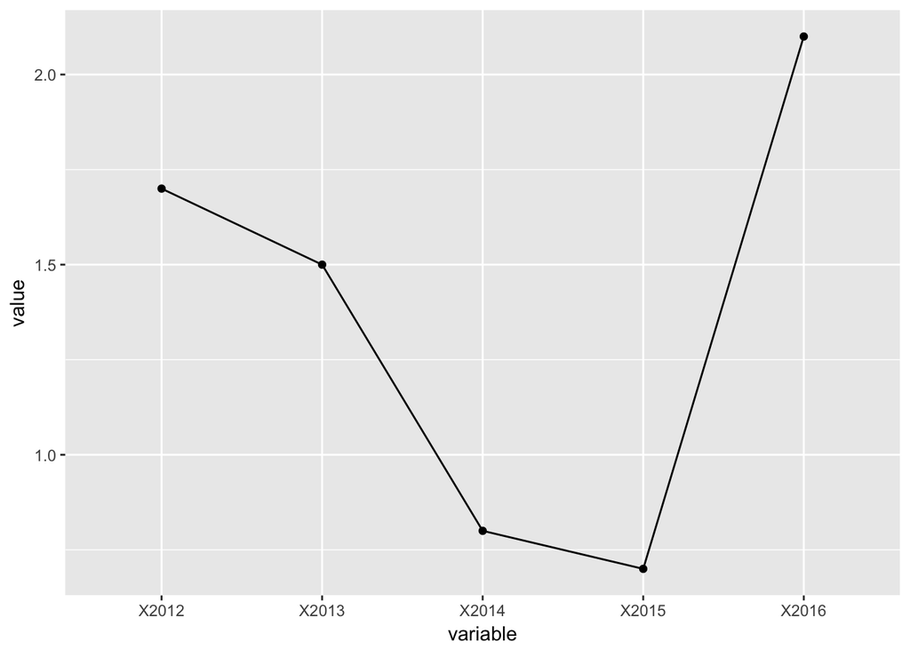

```r
new_consumer <- melt(consumer, id.vars=c("Item.and.group"))

ggplot(data=new_consumer, aes(x = variable, y = value, group=Item.and.group)) +
  geom_line() +
  geom_point()
```

Discuss seasonal patterns

- Seasonal patterns are difficult to discuss on a yearly data set, therefore yearly patterns will be discussed.

Answer: There was a dip below 1 for the years 2014 and 2015 with a strong rebound in 2016.

2. Average Gas Price Data

Average Gas Price Data

```r
gas_price <- read.csv(paste(dir, '/average_gas_prices.csv', sep = ''), header = TRUE)
```

Time Plot * Comparison could not be made because the CPI data given was yearly and the gas price data was monthly

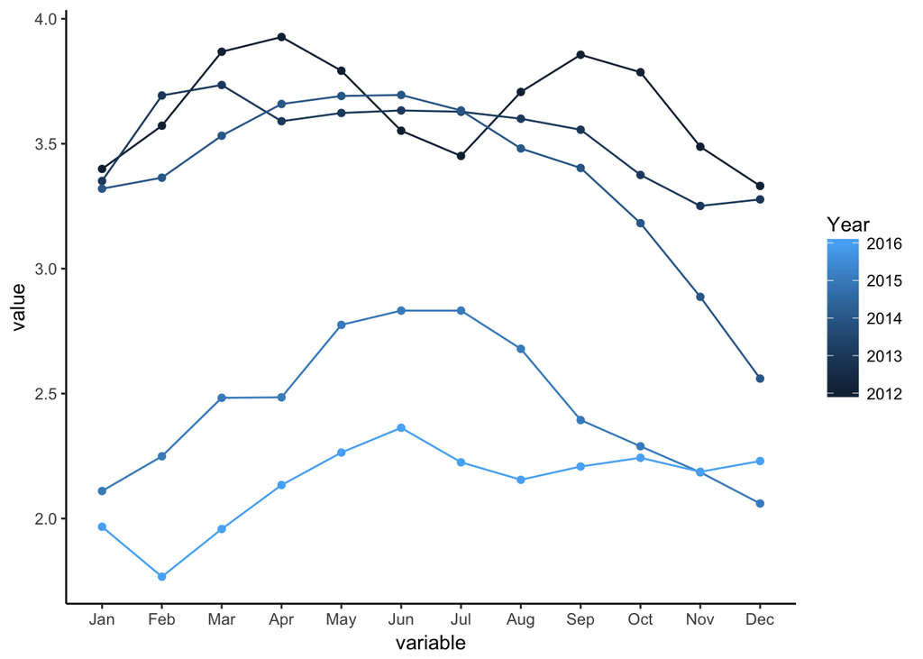

```r
new_gas_price <- melt(gas_price, id.vars=c("Year"))
new_gas_price$yyyy_mm = paste(new_gas_price$Year, match(new_gas_price$variable,month.abb), sep="-")

ggplot(data=new_gas_price, aes(x = variable, y = value, group=Year, color=Year)) +
  geom_line() +
  geom_point() +
  theme_classic()
```

#### 1-77

Use the following statement to answer the questions: > GPA percentiles for accepted transfer students: > 25th percentile, 3.68; > 75th percentile, 3.98. > Number of applications, 500; > Number accepted, 91.

1. What is the percentage of accepted transfer students whose grade point average (GPA) is below 3.68? Answer: 25%
2. What is the percentage of accepted transfer students with a GPA below 3.98? Answer: 75%
3. What is the percentage of accepted transfer students with GPA above 3.98? Answer: 25%
4. What is the percentage of accepted transfer students with GPA between 3.68 and 3.98? Answer: 50%
5. An accepted transfer student with a straight 4.0 is in what quartile? Answer: Upper
6. About how many accepted students per year are in the uppermost quartile? Answer: 22-23 Students
7. Suppose that only two of the 91 accepted transfer students have a GPA below 3.4. What is the percentile of the distribution of GPA for accepted transfer students that they represent? Answer: 2%
8. Roughly speaking, if the applying student has a GPA of 3.7, what are her chances of transferring successfully to the school? Answer: About 4.5%

#### 1-79 (No longer needed on most recent homework)

1. Download the data on the cumulative number of AIDS cases reported in the US and its age-range breakdown. Draw a pie chart.

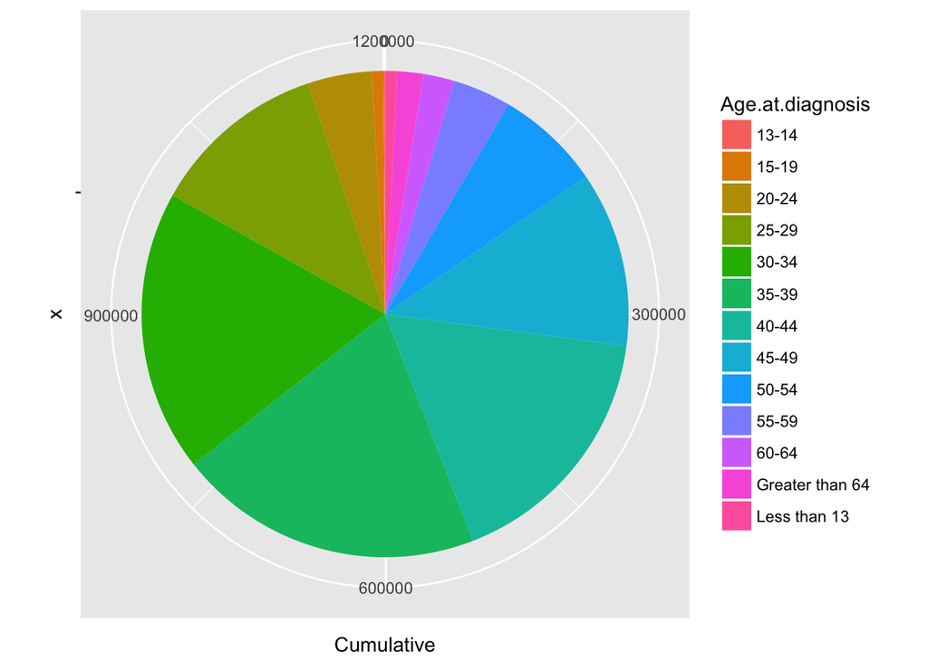

```r
aids_age <- read.csv(paste(dir, '/hiv_age.csv', sep = ''), header = TRUE)
ggplot(aids_age, aes(y = Cumulative, x = "", fill = Age.at.diagnosis)) +
  geom_col(width = 1) +
  coord_polar(theta = "y")
```

2. Download the race/ethnicity breakdown of the data. Draw a pie chart of the data.

```r
aids_race <- read.csv(paste(dir, '/hiv_race.csv', sep = ''), header = TRUE)
head(aids_race)
```

```
##                               Race Cumulative
## 1    American Indian/Alaska Native       3498
## 2                            Asian       9689
## 3           Black/African American     499734
## 4                         Hispanic     217650
## 5 Native Hawaiian/Pacific Islander        842
## 6                            White     436952
```

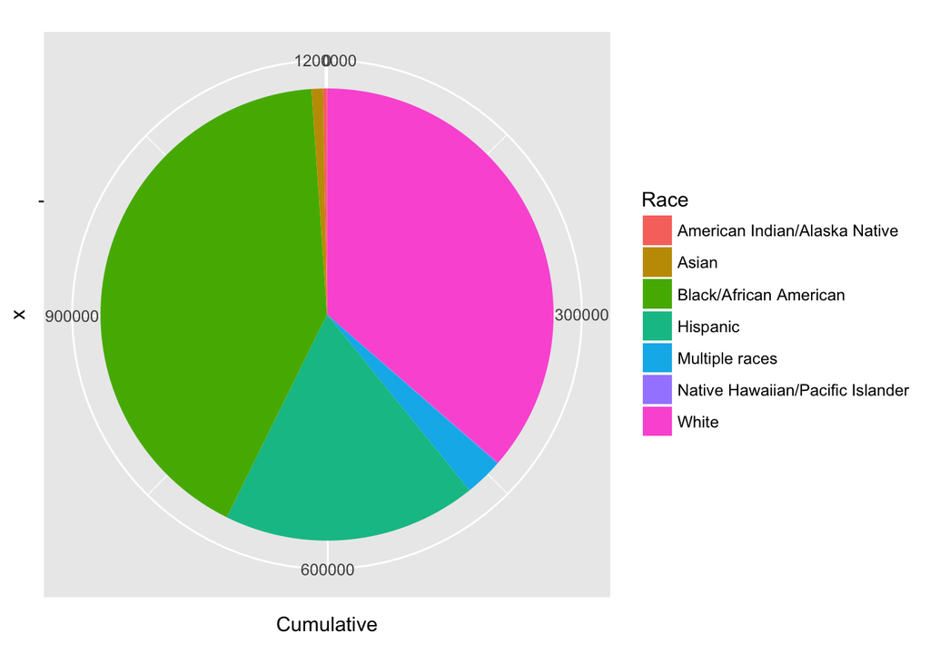

```r
ggplot(aids_race, aes(y = Cumulative, x = "", fill = Race)) +
  geom_col(width = 1) +
  coord_polar(theta = "y")
```

- Data Source: [CDC HIV Report](https://www.cdc.gov/hiv/pdf/library/reports/surveillance/cdc-hiv-surveillance-report-us.pdf) Table 2a

#### 2-31

```r
insurance_data <- read.csv(paste(dir, '/2_31_data.csv', sep = ''), header = TRUE)
head(insurance_data)
```

```
##                 Claims East South Midwest West
## 1      Hospitalization   75   128      29   52
## 2    Physician's Visit  233   514     104  251
## 3 Outpatient treatment  100   326      65   99
```

```r
col_sums <- c(sum(insurance_data$East),sum(insurance_data$South), sum(insurance_data$Midwest), sum(insurance_data$West))
row_sums <- rowSums(insurance_data[,2:5])
```

Compute column totals and row totals. What do they mean?

```r
col_sums
```

```
## [1] 408 968 198 402
```

Represents the total number of insurance claims per region.

```r
row_sums
```

```
## [1]  284 1102  590
```

Represents the total number of insurance claims per type of claim.

1. If a bill is chosen at random, what is the probability that it is from the Midwest?

```r
midwest_probabilty = (100 * col_sums[3] / sum(col_sums))
midwest_probabilty
```

```
## [1] 10.02024
```

2. What is the probability that a randomly chosen bill is from the East?

```r
east_probability = (100 * col_sums[1] / sum(col_sums))
east_probability
```

```
## [1] 20.64777
```

3. What is the probability that a randomly chosen bill is either from the Midwest or from the South? What is the relation between these two events?

```r
mid_south_probability = (100 * (col_sums[2] + col_sums[3]) / sum(col_sums))
mid_south_probability
```

```
## [1] 59.0081
```

Mutually exclusive

4. What is the probability that a randomly chosen bill is for hospitalization?

```r
hospital_probability = (100 * (row_sums[1]) / sum(row_sums))
hospital_probability
```

```
## [1] 14.37247
```

5. Given that a bill is for hospitalization, what is the probability that is is from the South?

```r
south_hospital_probability = (100 * (128) / row_sums[1])
south_hospital_probability
```

```
## [1] 45.07042
```

6. Given that a bill is from the East, what is the probabilty that it is for a physician’s visit?

```r
east_physician_probability = (100 * (233) / col_sums[1])
east_physician_probability
```

```
## [1] 57.10784
```

7. Given that a bill is for outpatient treament, what is the probabilty that it is from the West?

```r
outpatient_west = (100 * (99) / row_sums[3])
outpatient_west
```

```
## [1] 16.77966
```

8. What is the probabilty that a randomly chosen bill is either from the East or for outpatient treament (or both)?

```r
east_and_outpatient = (100 * (row_sums[3] + col_sums[1] - 100) / sum(col_sums))
east_and_outpatient
```

```
## [1] 45.44534
```

1. What is the probabilty that a randomly selected bill is either for hospitalization or from South (or both)?

```r
hospital_and_south = (100 * (row_sums[1] + col_sums[2] - 128) / sum(col_sums))
hospital_and_south
```

```
## [1] 56.88259
```

#### 2-61

```r
high = 0.6 * .15
medium = 0.3 * .7
low = 0.1 * .15

high / (high + medium + low)
```

```
## [1] 0.2857143
```